# Prospecção Séries Temporais

G4: Edinaldo de Alencar / Igor Freire / Ramon Araújo / Ricardo Ribeiro

16 de outubro de 2014

# Importação da base de dados

Pacote utilizado para leitura em formato de séries temporais:

```r
library(zoo)
```

Importar as bases de dados utilizando `read.zoo`:

```r
# Mudar para o diretório onde está a base de dados
setwd(paste("/Users/igorfreire/Documents/Mestrado/UFPA",
               "/Mineração de Dados/",
               "Trabalho 2 - Forecast", sep=""));

# Ler o .csv como uma série temporal (indexado pela data)
dataset_diario <- read.zoo(file = "dataset_diario.csv", sep = ";", dec = ",", header = TRUE,
        tz = "", index = 1, colClasses = c("fluxo"="numeric"), format = "%d/%m/%y", drop = FALSE)
# index ->  "The column names or numbers of the data frame in which the index/time is stored""
# em "format" usa-se y minusculo, pois a data está no formato dd/mm/yy

# Ler o .csv como uma série temporal (indexado pela data)
dataset_mensal <- read.zoo(file = "dataset_mensal.csv", sep = ";", dec = ",", header = TRUE,
        index = 1, tz = "", FUN = as.yearmon, format = "%m/%Y", drop = FALSE)
# em "format" usa-se Y maiúsculo, pois a data está no formato mm/yyyy
```

- `dataset_diario` é uma base com valores de fluxos diários de 2002 à 2009.
- `dataset_mensal` é uma base com os valores de fluxo mensais de 1992 à 2009.

### Notar que é necessário definir:

1. O caractere que separa as entradas no arquivo *.csv* (`sep =`)
2. O caractere separador de casas decimais do atributo numérico presente nas bases de dados (`dec =`)

# Inspeção do conjunto de dados

- Dataset diário:

```r
summary(dataset_diario)
```

```
##      Index                      dia          fluxo
##  Min.   :2002-01-01 00:00:00   dom:417   15806  :   3
##  1st Qu.:2004-01-01 06:00:00   qua:418   17568  :   3
##  Median :2005-12-31 12:00:00   qui:418   17777  :   3
##  Mean   :2005-12-31 12:00:00   sab:417   17914  :   3
##  3rd Qu.:2007-12-31 18:00:00   seg:417   19682  :   3
##  Max.   :2009-12-31 00:00:00   sex:417   19904  :   3
##                                ter:418   (Other):2904
```

**Observar** que a informação sobre os dias da semana é redundante, pois poderia ser obtida através de:

```r
dia <- weekdays(index(dataset_diario))
```

que tem como resultado, por exemplo, para as 10 primeiras amostras da base:

```r
head(dia, 10)
```

```
##  [1] "Terça Feira"   "Quarta Feira"  "Quinta Feira"  "Sexta Feira"
##  [5] "Sábado"        "Domingo"       "Segunda Feira" "Terça Feira"
##  [9] "Quarta Feira"  "Quinta Feira"
```

o qual pode ser confirmado comparando com as 10 primeiras entradas na coluna “dia” da base:

```r
head(dataset_diario[,1], 10)
```

```
## 2002-01-01 2002-01-02 2002-01-03 2002-01-04 2002-01-05 2002-01-06
##        ter        qua        qui        sex        sab        dom
## 2002-01-07 2002-01-08 2002-01-09 2002-01-10
##        seg        ter        qua        qui
```

```r
summary(dataset_mensal)
```

```
##      Index          fluxo
##  Min.   :1992   Min.   :261544
##  1st Qu.:1996   1st Qu.:408961
##  Median :2001   Median :529912
##  Mean   :2001   Mean   :548440
##  3rd Qu.:2005   3rd Qu.:662250
##  Max.   :2010   Max.   :982708
```

# Série temporal

Converter os dados para o formato de série temporal no R:

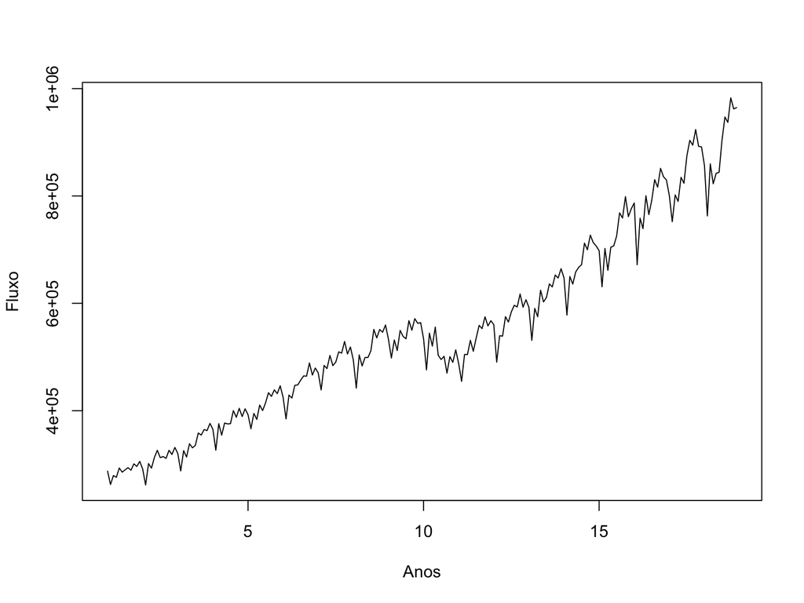

```r
tsMensal <- ts(dataset_mensal, frequency=12)
plot(tsMensal, xlab="Anos", ylab="Fluxo")
```

Decompor a série temporal em:

- Trend: padrão de crescimento ao longo do tempo
- Seasonal: padrão recorrente em um determinado período de tempo
- Irregular (random): parte irregular (ruidosa), sem padrão sasonal ou tendência

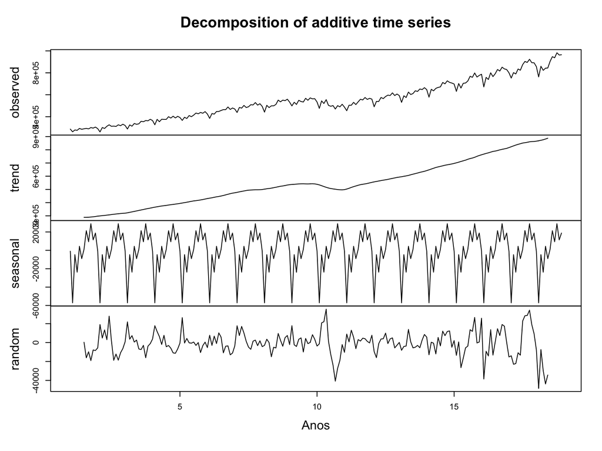

```r
plot(decompose(tsMensal), xlab="Anos")
```

Nota: ver tutoriais em (R. J. Hyndman 2014) e (Leek 2014)

# Separação dos dados

```r
tsMensalTrain <- window(tsMensal, end=(15-0.01)) # do começo até 15 anos
tsMensalTest <- window(tsMensal, start=15) # de 15 anos até o fim dos dados (18 anos)
```

Visualização

```r
tsMensalTest
```

```
##       Jan    Feb    Mar    Apr    May    Jun    Jul    Aug    Sep    Oct
## 15 698072 630797 702232 661458 704591 707014 725561 768589 758857 798840
## 16 786975 671785 758547 739111 800366 765350 792298 830373 816278 851496
## 17 800602 752107 801890 789809 834790 823701 874821 903554 894623 923699
## 18 856877 762838 859820 822665 842152 844119 903711 947233 937079 982708
##       Nov    Dec
## 15 761474 776307
## 16 835756 829870
## 17 892443 891430
## 18 962154 964567
```

# Moving Average (Médias Móveis)

Pacote utilizado

```r
library(forecast)
```

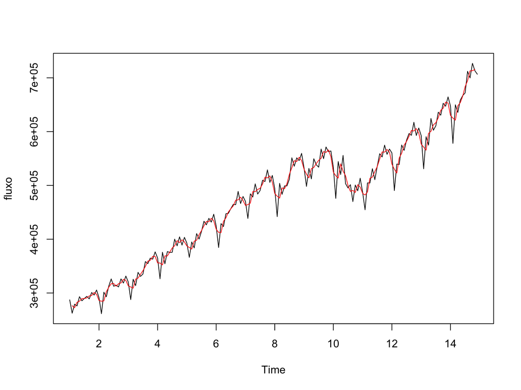

```r
plot(tsMensalTrain)
lines(ma(tsMensalTrain, order=3), col="red")
```

# Exponential Smoothing

Ver (R. J. Hyndman and Athanasopoulos 2013). O mesmo autor possui um livro somente sobre o assunto em (R. Hyndman et al. 2008).

Modelo:

```r
etsMensal <- ets(tsMensalTrain, model="MMM")
# Multiplicative Error
# Multiplicative trend
# Multiplicative Season
```

Prospecção:

```r
fcastMensal <- forecast(etsMensal)
```

Comparar predição com valores reais do conjunto de teste:

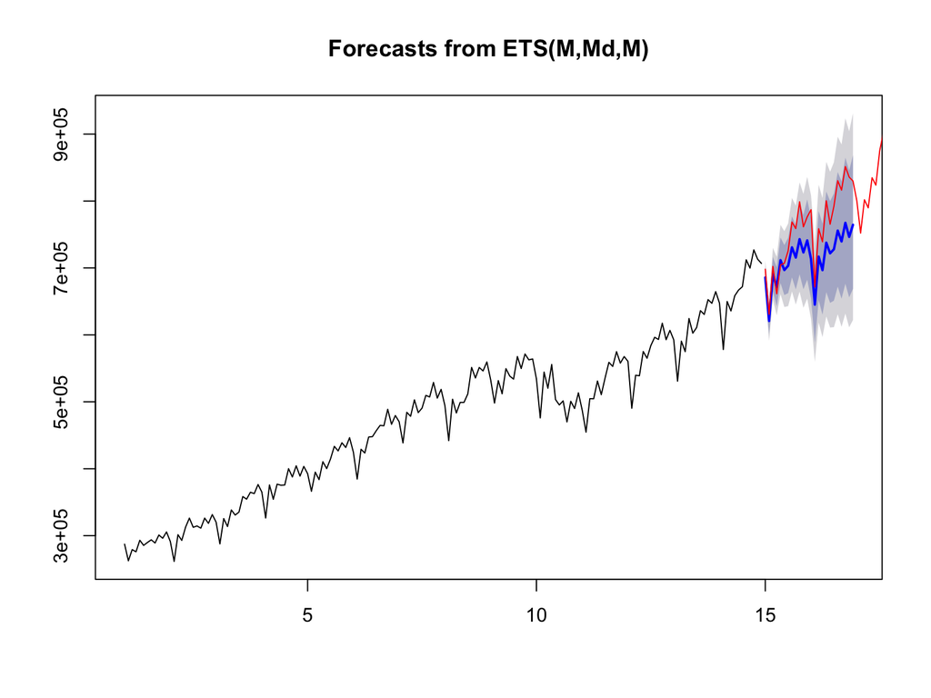

```r
plot(fcastMensal); lines(tsMensalTest, col="red")
```

# Acurácia

### MAPE: Mean absolute percentage error

$M = \frac{1}{n} \sum \limits_{t=1}^{n} \left| \frac{A_t - F_t}{A_t} \right|,$

onde $A_t$ é o valor verdadeiro, $F_t$ é o valor predito e $n$ é o número de amostras temporais preditas.

```r
accuracy(fcastMensal, tsMensalTest)
```

```
##                 ME  RMSE   MAE    MPE  MAPE   MASE      ACF1 Theil's U
## Training set   910  8952  6764 0.1729 1.438 0.1824 -0.005476        NA
## Test set     41853 50268 43278 5.2980 5.508 1.1668  0.757328     1.021
```

# Referências

Hyndman, Rob J. 2014. “Forecasting Time Series Using R.” http://robjhyndman.com/talks/MelbourneRUG.pdf.

Hyndman, Rob J, and George Athanasopoulos. 2013. *Forecasting: principles and Practice*. OTexts.

Hyndman, Rob, Anne B. Koehler, J. Keith Ord, and Ralph D. Snyder. 2008. *Forecasting with Exponential Smoothing: The State Space Approach (Springer Series in Statistics)*. 2008th ed. Springer. http://amazon.com/o/ASIN/3540719164/.

Leek, Jeffrey. 2014. “Practical Machine Learning - Lecture 27 - Forecasting.” Johns Hopkins Bloomberg School of Public Health. https://d396qusza40orc.cloudfront.net/predmachlearn/027forecasting.pdf.